# The Emotional Environment of Finn the Wolfhound: 2002 Validation using 2026 Methods

### Daniel Luna Miranda<sup>1</sup>

##### <sup>1</sup> Lehman College

[figure not shown]

# Introduction

While reading the chapter “Dog Years, Human Fears” from Representing Animals (Mangum 2002), a question came up: do we give human traits to our favorite companions? I recently wrote a story and some poetry about my own furry friends, Kobe and Sasha, projecting human emotions onto them to express how I feel about the people I care about.

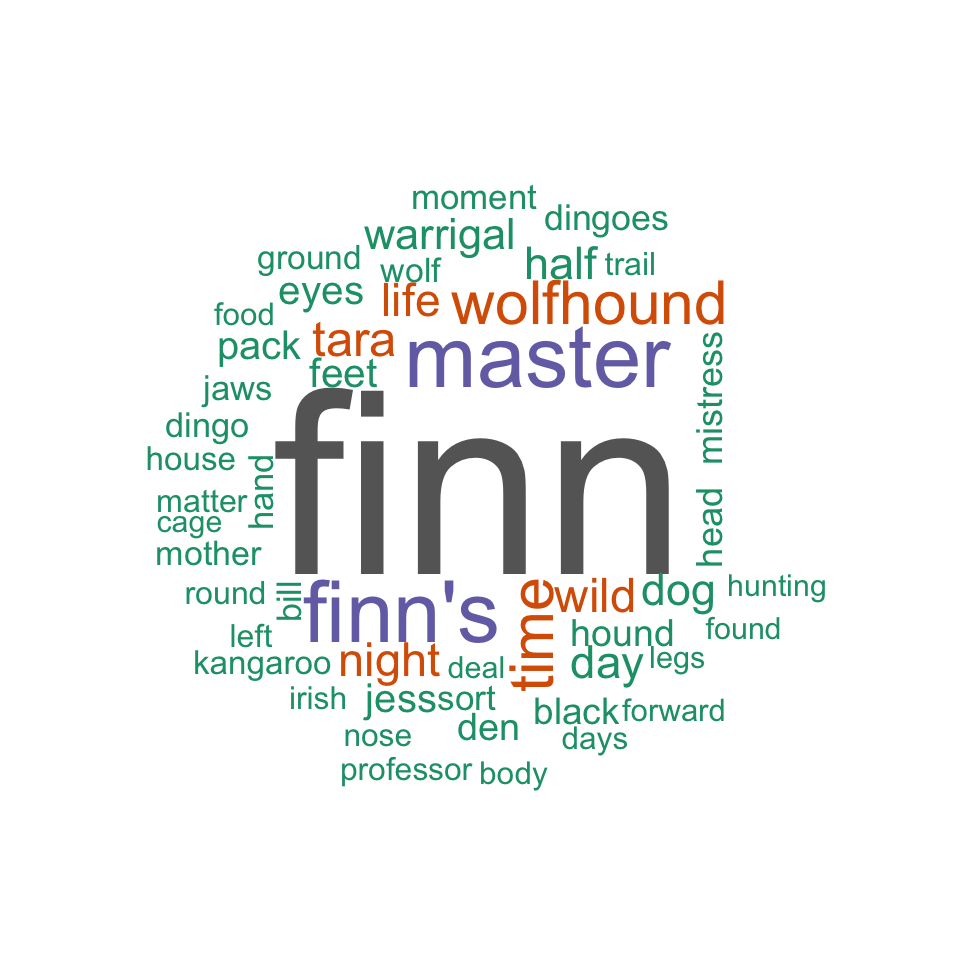

I wanted to see if the author mathematically manipulated the dog’s feelings, artificially shifting between “Trust” and “Fear” depending on whether Master appeared in the text.

# Objectives

The primary goal of this project is to use Natural Language Processing to mathematically map the emotional vocabulary of Finn the Wolfhound. I want to use statistical algorithms to see if the author artificially manipulated the narrative, forcing a spike in “Fear” words when Finn is in the wild and “Trust” words when he is with his master. Ultimately, this data will prove or reject Teresa Mangum’s theory that 19th-century authors intentionally selected these environments to mirror human anxieties about aging and isolation.

# Methods

To test the 2002 hypothesis, I built an NLP and statistical pipeline using R:

- Data cleaning and wrangling: Retrieved the text via Project Gutenberg, used Regular Expressions (Regex) to align chapter titles, and tokenized the text to filter out standard stop words.
- Exploratory Data Analysis: Initial word counts revealed “master” as the most common word (excluding Finn), perfectly aligning with Mangum’s theories.
- Algorithmic Stemming: Applied the Snowball Stemming Algorithm (SnowballC) to group sentiments.
- Sentiment Analysis: Used the NRC Emotion Lexicon to isolate and measure the frequencies of “Trust” and “Fear” across the text.
- Machine Learning Models: Initially ran unsupervised clustering algorithms to search for emotional timelines, but abandoned this approach when the algorithms isolated extreme outlier chapters rather than narrative environments.(Hvitfeldt and Silge 2021)
- Statistical Inference: Used a median split on the frequency of the word “master” to divide the book into “Domestic” and “Wild” halves, then executed a Pearson’s Chi-Squared Test to prove if the emotional shifts were statistically significant.

# Results

Going into this analysis without knowing the plot allowed the data to lead the narrative. The numbers revealed a stark and deliberate emotional contrast between the two environments. Sentiment Distribution Mentions of “Trust” were heavily correlated with domestic figures, while “Fear” vocabulary dominated scenes where Finn was isolated.

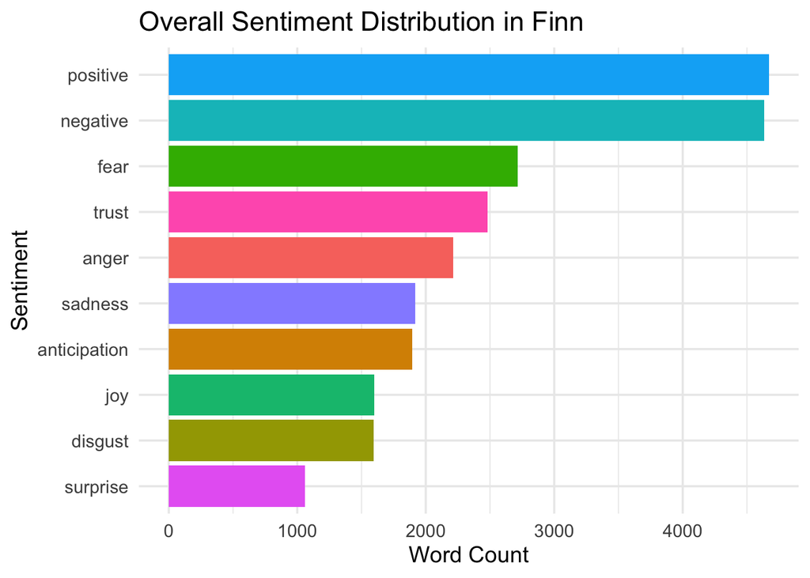

Statistical Proof Dividing the novel into “Master Present” and “Master Absent” environments yielded definitive mathematical results:

Table 1: Table 2: Word Counts: Environment vs. Emotion

|  | fear | trust |
| --- | --- | --- |
| Domestic (Master) | 743 | 1075 |
| Wild (No Master) | 1971 | 1406 |

A Pearson’s Chi-squared test with Yates’ continuity correction revealed a massive, highly significant structural shift in the author’s vocabulary (X-squared = 144.3, df = 1, p-value < 0.001)

# Conclusion

[figure not shown]

# Next Steps

Mangum’s text raises further questions about whether authors project specific human characteristics primarily onto dogs, or if this extends to other working animals. Future research could apply this same NLP pipeline to Black Beauty, to explore how sentiments shift when analyzing human behavior toward horses.

# References

Hvitfeldt, Emil, and Julia Silge. 2021. *Supervised Machine Learning for Text Analysis in r*. Chapman; Hall/CRC. https://smltar.com/mlclassification.

Mangum, Teresa. 2002. “Dog Years, Human Fears.” In *Representing Animals*, edited by Nigel Rothfels. Indiana University Press.